# Risk Factor Analysis

## Outcome Variable

**Outcome Variable:** ever_swasted

## Predictor Variables

**Intervention Variable:** mwtkg

**Adjustment Set:**

- arm
- W_mage
- meducyrs
- feducyrs
- hhwealth_quart
- W_nchldlt5
- brthmon
- W_parity
- delta_W_mage
- delta_meducyrs
- delta_feducyrs
- delta_hhwealth_quart
- delta_W_nchldlt5
- delta_brthmon
- delta_W_parity

## Stratifying Variables

The analysis was stratified on these variable(s):

- agecat
- studyid
- country

## Data Summary

| agecat | studyid | country | mwtkg | ever_swasted | n_cell | n |
| --- | --- | --- | --- | --- | --- | --- |
| 0-24 months | iLiNS-Zinc | BURKINA FASO | >=58 kg | 0 | 906 | 3217 |
| 0-24 months | iLiNS-Zinc | BURKINA FASO | >=58 kg | 1 | 31 | 3217 |
| 0-24 months | iLiNS-Zinc | BURKINA FASO | <52 kg | 0 | 1124 | 3217 |
| 0-24 months | iLiNS-Zinc | BURKINA FASO | <52 kg | 1 | 77 | 3217 |
| 0-24 months | iLiNS-Zinc | BURKINA FASO | [52-58) kg | 0 | 1033 | 3217 |
| 0-24 months | iLiNS-Zinc | BURKINA FASO | [52-58) kg | 1 | 46 | 3217 |
| 0-24 months | JiVitA-3 | BANGLADESH | >=58 kg | 0 | 634 | 26925 |
| 0-24 months | JiVitA-3 | BANGLADESH | >=58 kg | 1 | 27 | 26925 |
| 0-24 months | JiVitA-3 | BANGLADESH | <52 kg | 0 | 23001 | 26925 |
| 0-24 months | JiVitA-3 | BANGLADESH | <52 kg | 1 | 1505 | 26925 |
| 0-24 months | JiVitA-3 | BANGLADESH | [52-58) kg | 0 | 1645 | 26925 |
| 0-24 months | JiVitA-3 | BANGLADESH | [52-58) kg | 1 | 113 | 26925 |
| 0-24 months | LCNI-5 | MALAWI | >=58 kg | 0 | 113 | 838 |
| 0-24 months | LCNI-5 | MALAWI | >=58 kg | 1 | 1 | 838 |
| 0-24 months | LCNI-5 | MALAWI | <52 kg | 0 | 500 | 838 |
| 0-24 months | LCNI-5 | MALAWI | <52 kg | 1 | 4 | 838 |
| 0-24 months | LCNI-5 | MALAWI | [52-58) kg | 0 | 217 | 838 |
| 0-24 months | LCNI-5 | MALAWI | [52-58) kg | 1 | 3 | 838 |
| 0-24 months | MAL-ED | BANGLADESH | >=58 kg | 0 | 45 | 254 |
| 0-24 months | MAL-ED | BANGLADESH | >=58 kg | 1 | 3 | 254 |
| 0-24 months | MAL-ED | BANGLADESH | <52 kg | 0 | 144 | 254 |
| 0-24 months | MAL-ED | BANGLADESH | <52 kg | 1 | 18 | 254 |
| 0-24 months | MAL-ED | BANGLADESH | [52-58) kg | 0 | 44 | 254 |
| 0-24 months | MAL-ED | BANGLADESH | [52-58) kg | 1 | 0 | 254 |
| 0-24 months | MAL-ED | BRAZIL | >=58 kg | 0 | 140 | 221 |
| 0-24 months | MAL-ED | BRAZIL | >=58 kg | 1 | 3 | 221 |
| 0-24 months | MAL-ED | BRAZIL | <52 kg | 0 | 42 | 221 |
| 0-24 months | MAL-ED | BRAZIL | <52 kg | 1 | 0 | 221 |
| 0-24 months | MAL-ED | BRAZIL | [52-58) kg | 0 | 35 | 221 |
| 0-24 months | MAL-ED | BRAZIL | [52-58) kg | 1 | 1 | 221 |

[output cut: 72 more lines]

The following strata were considered:

- agecat: 0-24 months, studyid: iLiNS-Zinc, country: BURKINA FASO
- agecat: 0-24 months, studyid: JiVitA-3, country: BANGLADESH
- agecat: 0-24 months, studyid: LCNI-5, country: MALAWI
- agecat: 0-24 months, studyid: MAL-ED, country: BANGLADESH
- agecat: 0-24 months, studyid: MAL-ED, country: BRAZIL
- agecat: 0-24 months, studyid: MAL-ED, country: INDIA
- agecat: 0-24 months, studyid: MAL-ED, country: NEPAL
- agecat: 0-24 months, studyid: MAL-ED, country: PERU
- agecat: 0-24 months, studyid: MAL-ED, country: SOUTH AFRICA
- agecat: 0-24 months, studyid: MAL-ED, country: TANZANIA, UNITED REPUBLIC OF
- agecat: 0-24 months, studyid: NIH-Birth, country: BANGLADESH
- agecat: 0-24 months, studyid: NIH-Crypto, country: BANGLADESH
- agecat: 0-24 months, studyid: PROBIT, country: BELARUS
- agecat: 0-24 months, studyid: PROVIDE, country: BANGLADESH
- agecat: 0-24 months, studyid: SAS-CompFeed, country: INDIA
- agecat: 0-24 months, studyid: TanzaniaChild2, country: TANZANIA, UNITED REPUBLIC OF
- agecat: 0-24 months, studyid: ZVITAMBO, country: ZIMBABWE

### Dropped Strata

Some strata were dropped due to rare outcomes:

- agecat: 0-24 months, studyid: LCNI-5, country: MALAWI
- agecat: 0-24 months, studyid: MAL-ED, country: BANGLADESH
- agecat: 0-24 months, studyid: MAL-ED, country: BRAZIL
- agecat: 0-24 months, studyid: MAL-ED, country: INDIA
- agecat: 0-24 months, studyid: MAL-ED, country: NEPAL
- agecat: 0-24 months, studyid: MAL-ED, country: PERU
- agecat: 0-24 months, studyid: MAL-ED, country: SOUTH AFRICA
- agecat: 0-24 months, studyid: MAL-ED, country: TANZANIA, UNITED REPUBLIC OF
- agecat: 0-24 months, studyid: PROVIDE, country: BANGLADESH

## Methods Detail

We're interested in the causal parameters $E[Y_a]$ for all values of $a \in \mathcal{A}$. These parameters represent the mean outcome if, possibly contrary to fact, we intervened to set all units to have $A=a$. Under the randomization and positivity assumptions, these are identified by the statistical parameters $\psi_a=E_W[E_{Y|A,W}(Y|A=a,W)]$. In addition, we're interested in the mean of $Y$, $E[Y]$ under no intervention (the observed mean). We will estimate these parameters by using SuperLearner to fit the relevant likelihood factors -- $E_{Y|A,W}(Y|A=a,W)$ and $p(A=a|W)$, and then updating our likelihood fit using a joint TMLE.

For unadjusted analyses ($W=\{\}$), initial likelihoods were estimated using Lrnr_glm to estimate the simple $E(Y|A)$ and Lrnr_mean to estimate $p(A)$. For adjusted analyses, a small library containing Lrnr_glmnet, Lrnr_xgboost, and Lrnr_mean was used.

Having estimated these parameters, we will then use the delta method to estimate relative risks and attributable risks relative to a prespecified baseline level of $A$.

# Results Detail

## Results Plots

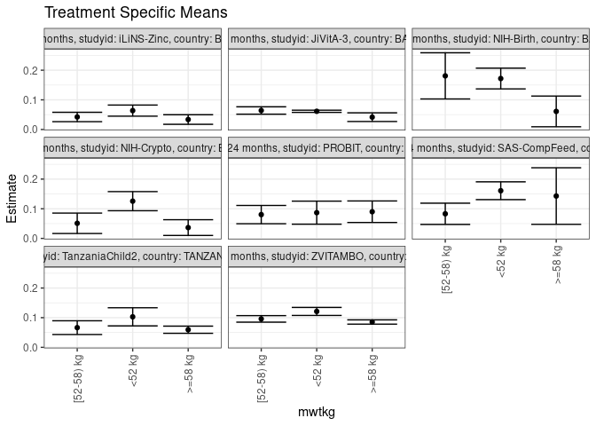

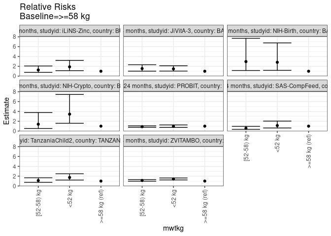

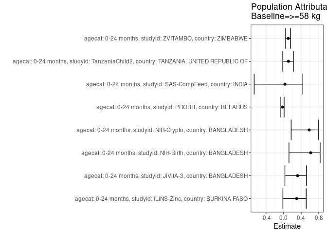

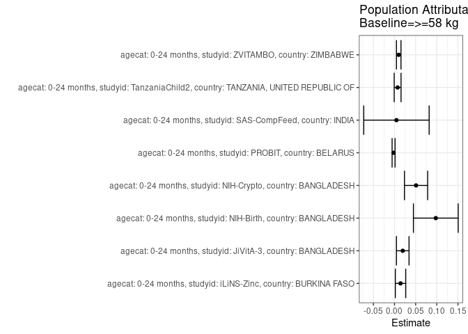

## Results Table

### Parameter: TSM

| agecat | studyid | country | intervention_level | baseline_level | estimate | ci_lower | ci_upper |
| --- | --- | --- | --- | --- | --- | --- | --- |
| 0-24 months | iLiNS-Zinc | BURKINA FASO | >=58 kg | NA | 0.0336313 | 0.0174790 | 0.0497836 |
| 0-24 months | iLiNS-Zinc | BURKINA FASO | <52 kg | NA | 0.0636890 | 0.0449428 | 0.0824352 |
| 0-24 months | iLiNS-Zinc | BURKINA FASO | [52-58) kg | NA | 0.0422363 | 0.0264413 | 0.0580312 |
| 0-24 months | JiVitA-3 | BANGLADESH | >=58 kg | NA | 0.0416302 | 0.0270366 | 0.0562239 |
| 0-24 months | JiVitA-3 | BANGLADESH | <52 kg | NA | 0.0614274 | 0.0577044 | 0.0651505 |
| 0-24 months | JiVitA-3 | BANGLADESH | [52-58) kg | NA | 0.0640660 | 0.0515940 | 0.0765381 |
| 0-24 months | NIH-Birth | BANGLADESH | >=58 kg | NA | 0.0609756 | 0.0091427 | 0.1128086 |
| 0-24 months | NIH-Birth | BANGLADESH | <52 kg | NA | 0.1718750 | 0.1369118 | 0.2068382 |
| 0-24 months | NIH-Birth | BANGLADESH | [52-58) kg | NA | 0.1808511 | 0.1029803 | 0.2587218 |
| 0-24 months | NIH-Crypto | BANGLADESH | >=58 kg | NA | 0.0364583 | 0.0099295 | 0.0629872 |
| 0-24 months | NIH-Crypto | BANGLADESH | <52 kg | NA | 0.1256158 | 0.0933571 | 0.1578744 |
| 0-24 months | NIH-Crypto | BANGLADESH | [52-58) kg | NA | 0.0509554 | 0.0165343 | 0.0853765 |
| 0-24 months | PROBIT | BELARUS | >=58 kg | NA | 0.0899681 | 0.0536446 | 0.1262917 |
| 0-24 months | PROBIT | BELARUS | <52 kg | NA | 0.0868116 | 0.0479818 | 0.1256413 |
| 0-24 months | PROBIT | BELARUS | [52-58) kg | NA | 0.0803273 | 0.0494580 | 0.1111967 |
| 0-24 months | SAS-CompFeed | INDIA | >=58 kg | NA | 0.1429174 | 0.0475331 | 0.2383016 |
| 0-24 months | SAS-CompFeed | INDIA | <52 kg | NA | 0.1608284 | 0.1307957 | 0.1908611 |
| 0-24 months | SAS-CompFeed | INDIA | [52-58) kg | NA | 0.0830284 | 0.0472111 | 0.1188457 |
| 0-24 months | TanzaniaChild2 | TANZANIA, UNITED REPUBLIC OF | >=58 kg | NA | 0.0593889 | 0.0472722 | 0.0715055 |
| 0-24 months | TanzaniaChild2 | TANZANIA, UNITED REPUBLIC OF | <52 kg | NA | 0.1028914 | 0.0722758 | 0.1335069 |
| 0-24 months | TanzaniaChild2 | TANZANIA, UNITED REPUBLIC OF | [52-58) kg | NA | 0.0663880 | 0.0432276 | 0.0895483 |
| 0-24 months | ZVITAMBO | ZIMBABWE | >=58 kg | NA | 0.0853886 | 0.0781430 | 0.0926342 |
| 0-24 months | ZVITAMBO | ZIMBABWE | <52 kg | NA | 0.1210495 | 0.1075580 | 0.1345409 |
| 0-24 months | ZVITAMBO | ZIMBABWE | [52-58) kg | NA | 0.0958455 | 0.0848438 | 0.1068473 |

### Parameter: E(Y)

| agecat | studyid | country | intervention_level | baseline_level | estimate | ci_lower | ci_upper |
| --- | --- | --- | --- | --- | --- | --- | --- |
| 0-24 months | iLiNS-Zinc | BURKINA FASO | NA | NA | 0.0478707 | 0.0359037 | 0.0598376 |
| 0-24 months | JiVitA-3 | BANGLADESH | NA | NA | 0.0610956 | 0.0576148 | 0.0645765 |
| 0-24 months | NIH-Birth | BANGLADESH | NA | NA | 0.1586538 | 0.1299648 | 0.1873429 |
| 0-24 months | NIH-Crypto | BANGLADESH | NA | NA | 0.0874172 | 0.0672569 | 0.1075775 |
| 0-24 months | PROBIT | BELARUS | NA | NA | 0.0877868 | 0.0528398 | 0.1227338 |
| 0-24 months | SAS-CompFeed | INDIA | NA | NA | 0.1475300 | 0.1183178 | 0.1767423 |
| 0-24 months | TanzaniaChild2 | TANZANIA, UNITED REPUBLIC OF | NA | NA | 0.0667517 | 0.0566626 | 0.0768408 |
| 0-24 months | ZVITAMBO | ZIMBABWE | NA | NA | 0.0953617 | 0.0899142 | 0.1008093 |

### Parameter: RR

| agecat | studyid | country | intervention_level | baseline_level | estimate | ci_lower | ci_upper |
| --- | --- | --- | --- | --- | --- | --- | --- |
| 0-24 months | iLiNS-Zinc | BURKINA FASO | >=58 kg | >=58 kg | 1.0000000 | 1.0000000 | 1.0000000 |
| 0-24 months | iLiNS-Zinc | BURKINA FASO | <52 kg | >=58 kg | 1.8937427 | 1.1181090 | 3.2074346 |
| 0-24 months | iLiNS-Zinc | BURKINA FASO | [52-58) kg | >=58 kg | 1.2558624 | 0.7649522 | 2.0618154 |
| 0-24 months | JiVitA-3 | BANGLADESH | >=58 kg | >=58 kg | 1.0000000 | 1.0000000 | 1.0000000 |
| 0-24 months | JiVitA-3 | BANGLADESH | <52 kg | >=58 kg | 1.4755485 | 1.0296621 | 2.1145222 |
| 0-24 months | JiVitA-3 | BANGLADESH | [52-58) kg | >=58 kg | 1.5389302 | 1.0195863 | 2.3228109 |
| 0-24 months | NIH-Birth | BANGLADESH | >=58 kg | >=58 kg | 1.0000000 | 1.0000000 | 1.0000000 |
| 0-24 months | NIH-Birth | BANGLADESH | <52 kg | >=58 kg | 2.8187500 | 1.1761332 | 6.7554864 |
| 0-24 months | NIH-Birth | BANGLADESH | [52-58) kg | >=58 kg | 2.9659574 | 1.1437460 | 7.6913089 |
| 0-24 months | NIH-Crypto | BANGLADESH | >=58 kg | >=58 kg | 1.0000000 | 1.0000000 | 1.0000000 |
| 0-24 months | NIH-Crypto | BANGLADESH | <52 kg | >=58 kg | 3.4454609 | 1.5926859 | 7.4535732 |
| 0-24 months | NIH-Crypto | BANGLADESH | [52-58) kg | >=58 kg | 1.3976342 | 0.5178396 | 3.7721749 |
| 0-24 months | PROBIT | BELARUS | >=58 kg | >=58 kg | 1.0000000 | 1.0000000 | 1.0000000 |
| 0-24 months | PROBIT | BELARUS | <52 kg | >=58 kg | 0.9649144 | 0.7449442 | 1.2498382 |
| 0-24 months | PROBIT | BELARUS | [52-58) kg | >=58 kg | 0.8928420 | 0.7536012 | 1.0578100 |
| 0-24 months | SAS-CompFeed | INDIA | >=58 kg | >=58 kg | 1.0000000 | 1.0000000 | 1.0000000 |
| 0-24 months | SAS-CompFeed | INDIA | <52 kg | >=58 kg | 1.1253245 | 0.6248814 | 2.0265530 |
| 0-24 months | SAS-CompFeed | INDIA | [52-58) kg | >=58 kg | 0.5809539 | 0.3504499 | 0.9630689 |
| 0-24 months | TanzaniaChild2 | TANZANIA, UNITED REPUBLIC OF | >=58 kg | >=58 kg | 1.0000000 | 1.0000000 | 1.0000000 |
| 0-24 months | TanzaniaChild2 | TANZANIA, UNITED REPUBLIC OF | <52 kg | >=58 kg | 1.7325025 | 1.2076006 | 2.4855610 |
| 0-24 months | TanzaniaChild2 | TANZANIA, UNITED REPUBLIC OF | [52-58) kg | >=58 kg | 1.1178523 | 0.7462146 | 1.6745768 |
| 0-24 months | ZVITAMBO | ZIMBABWE | >=58 kg | >=58 kg | 1.0000000 | 1.0000000 | 1.0000000 |
| 0-24 months | ZVITAMBO | ZIMBABWE | <52 kg | >=58 kg | 1.4176298 | 1.2322757 | 1.6308641 |
| 0-24 months | ZVITAMBO | ZIMBABWE | [52-58) kg | >=58 kg | 1.1224625 | 0.9730983 | 1.2947531 |

### Parameter: PAR

| agecat | studyid | country | intervention_level | baseline_level | estimate | ci_lower | ci_upper |
| --- | --- | --- | --- | --- | --- | --- | --- |
| 0-24 months | iLiNS-Zinc | BURKINA FASO | >=58 kg | NA | 0.0142394 | 0.0019340 | 0.0265448 |
| 0-24 months | JiVitA-3 | BANGLADESH | >=58 kg | NA | 0.0194654 | 0.0045681 | 0.0343627 |
| 0-24 months | NIH-Birth | BANGLADESH | >=58 kg | NA | 0.0976782 | 0.0447291 | 0.1506274 |
| 0-24 months | NIH-Crypto | BANGLADESH | >=58 kg | NA | 0.0509589 | 0.0235314 | 0.0783864 |
| 0-24 months | PROBIT | BELARUS | >=58 kg | NA | -0.0021813 | -0.0056858 | 0.0013231 |
| 0-24 months | SAS-CompFeed | INDIA | >=58 kg | NA | 0.0046127 | -0.0727406 | 0.0819660 |
| 0-24 months | TanzaniaChild2 | TANZANIA, UNITED REPUBLIC OF | >=58 kg | NA | 0.0073628 | -0.0007377 | 0.0154634 |
| 0-24 months | ZVITAMBO | ZIMBABWE | >=58 kg | NA | 0.0099731 | 0.0046264 | 0.0153198 |

### Parameter: PAF

| agecat | studyid | country | intervention_level | baseline_level | estimate | ci_lower | ci_upper |
| --- | --- | --- | --- | --- | --- | --- | --- |
| 0-24 months | iLiNS-Zinc | BURKINA FASO | >=58 kg | NA | 0.2974557 | -0.0161459 | 0.5142740 |
| 0-24 months | JiVitA-3 | BANGLADESH | >=58 kg | NA | 0.3186054 | 0.0297632 | 0.5214585 |
| 0-24 months | NIH-Birth | BANGLADESH | >=58 kg | NA | 0.6156689 | 0.1221060 | 0.8317446 |
| 0-24 months | NIH-Crypto | BANGLADESH | >=58 kg | NA | 0.5829388 | 0.1719680 | 0.7899356 |
| 0-24 months | PROBIT | BELARUS | >=58 kg | NA | -0.0248480 | -0.0631596 | 0.0120830 |
| 0-24 months | SAS-CompFeed | INDIA | >=58 kg | NA | 0.0312660 | -0.6698026 | 0.4379902 |
| 0-24 months | TanzaniaChild2 | TANZANIA, UNITED REPUBLIC OF | >=58 kg | NA | 0.1103018 | -0.0186180 | 0.2229051 |
| 0-24 months | ZVITAMBO | ZIMBABWE | >=58 kg | NA | 0.1045820 | 0.0470132 | 0.1586730 |